# INFS3201/7202: Django Admin Panel (Optional Self-Paced Tutorial)

The Django admin panel is a built-in web interface that makes it easy to manage the data in your application. Once you’ve defined your models, the admin panel lets you **create, read, update, and delete (CRUD)** entries for those models—without writing any extra views or forms.

All you need to do is register your models with the admin interface using a simple configuration in `admin.py`. Django takes care of the rest, generating a full-featured interface for your models, complete with search, filtering, and validation.

**Important**

⚠️ The admin panel is **not meant for your app’s end users**. It’s designed for developers, staff, or site administrators to manage content behind the scenes. If you need custom views or user-facing forms, you’ll build those separately.

The admin panel is a powerful tool for quickly managing data during development and for backend content management in production (with proper access controls).

## Recap on the Models Setup in Lab 3

In Lab 3 you added the following models in `resumeapp/models.py`. It is ok if you added a few more fields to the models by completing the challenge activity.

```python
from django.contrib.auth.models import User
from django.db import models

class UserDetail(models.Model):
    user = models.OneToOneField(User, on_delete=models.CASCADE)  # Link to Django's built-in User model
    firstname = models.CharField(max_length=100)
    surname = models.CharField(max_length=100)
    mobileno = models.CharField(max_length=15, blank=True, null=True)

    def __str__(self):
        return f"Details for {self.user.username}"

class Qualification(models.Model):
    user = models.ForeignKey(UserDetail, on_delete=models.CASCADE)  # One user can have many qualifications
    title = models.CharField(max_length=200)
    university = models.CharField(max_length=200)
    date_completed = models.DateField()

    def __str__(self):
        return f"{self.title} from {self.university} (User: {self.user.user.username})"

class WorkExperience(models.Model):
    user = models.ForeignKey(UserDetail, on_delete=models.CASCADE)  # One user can have many jobs
    job_title = models.CharField(max_length=200)
    company = models.CharField(max_length=200)
    start_date = models.DateField()
    end_date = models.DateField(blank=True, null=True)  # Can be blank for current jobs
    description = models.TextField(blank=True, null=True)

    def __str__(self):
        return f"{self.job_title} at {self.company} (User: {self.user.user.username})"
```

## 🛠️ Configuring Django Admin

Now that we have **models** for user details, qualifications, and work experience, let’s configure Django’s **built-in admin interface** to manage our data easily! 🚀

Django provides an **admin panel** that allows us to:

- **View, add, update, and delete** database records without writing SQL.
- **Quickly test our models** before integrating them into views.
- **Manage users and permissions** for our web app.

Let’s set it up! 🎯

**Step 1: Create a Superuser**

Before accessing the Django admin panel, we need to create an **admin account**.

Run the following command:

```bash
python3.12 manage.py createsuperuser
```

**Enter the required details:**  
- **Username:** *(Choose an admin username)*  
- **Email Address:** *(Optional)*  
- **Password:** *(Enter a secure password and confirm)*

If successful, you should see:

```
Username (leave blank to use 'studentusername'):
Email address: studentusername@student.uq.edu.au
Password:
Password (again):
Superuser created successfully.
```

**Step 2: Additional Security Settings to Get the Admin Panel Working**

CSRF (Cross-Site Request Forgery) is a security vulnerability where a malicious website tricks a logged-in user into submitting a request to your site without their knowledge—like posting a form or changing settings. Django protects against this by checking for a valid CSRF token on form submissions.

We need to do some additional config to get the Admin panel working.

Add the following line to your `settings.py` file:

```bash
CSRF_TRUSTED_ORIGINS = ["https://yourzoneid.uqcloud.net", "https://infs3202-yourzoneid.uqcloud.net"]
```

This setting tells Django to trust these specific domains when handling secure (HTTPS) POST requests. Without it, Django might block valid requests—especially in cloud-hosted environments like UQCloud—thinking they’re potential CSRF attacks.

**Step 3: Setting up Static Files**

In Django, `collectstatic` is used to gather all static files (like CSS, JavaScript, and images) from your apps into a single directory so they can be served efficiently

Make a new folder in `/var/www/htdocs/` called `resumebuilder_static`. You can do this using Linux commands (e.g. `mkdir`) or via VSCode Online.

Change the `STATIC_URL = 'static/'` to have the name of your app in the path (so that you can have multiple static files directories). Add the additional code to to set `STATIC_ROOT`:

```bash
STATIC_URL = 'resumebuilder_static/'

# The directory where collectstatic will place all static files
STATIC_ROOT = "/var/www/htdocs/resumebuilder_static/"  # Used in production
```

`/var/www/htdocs/` is already set to serve static files in our `nginx` configuration. We can place Django’s static files in this path and all the files (css and js) will then be available via `https://infs3202-yourzoneid.uqcloud.net/resumebuilder_static”

Now run the `collectstatic` command to move all the stylesheets and js files for the Django Admin panel to a static files folder:

```bash
python3.12 manage.py collectstatic
```

You should see the following message:

```bash
127 static files copied to '/var/www/htdocs/resumebuilder_static/'
```

**Step 4: Register Models in Django Admin**

By default, Django’s admin panel already manages **User accounts**. We need to **register our custom models** to make them manageable from the admin interface.

**Open `resumeapp/admin.py`** and add the following code:

```python
from django.contrib import admin
from .models import UserDetail, Qualification, WorkExperience

admin.site.register(UserDetail)
admin.site.register(Qualification)
admin.site.register(WorkExperience)
```

This tells Django **which models should be visible in the admin panel**.

**Step 5: Use the Admin Panel to Enter data**

Run the Django Web server again if it was stopped. Also note that you may need to change your port depending on your nginx settings.

```bash
python3.12 manage.py runserver 0.0.0.0:8000
```

Now, open your browser and go to:

```
https://yourid.uqcloud.net/resumebuilder/admin/
```

✅ You should see the **Django Admin Login Page**! 🎉

Enter the **admin username and password** you created earlier. Click **“Log in”**.  
You should now see the **Django admin dashboard** with the models you registered!

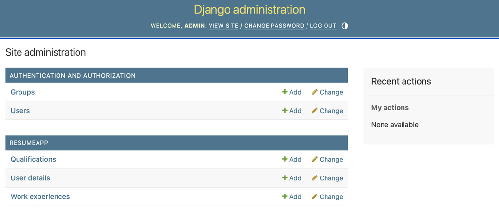

Now that you have access, let’s **add some data**:

Click on **“User Details”** → **“Add User Details”**

- Select an existing **Django User**
- Enter a **phone number**
- Click **“Save”**

Click on **“Qualifications”** → **“Add Qualification”**

- Select a **User Details** record
- Enter a **degree title**, **university**, and **completion date**
- Click **“Save”**

Add a few qualifications for the user.

Click on **“Work Experience”** → **“Add Work Experience”**

- Select a **User Details** record
- Enter a **job title**, **company name**, **start and end date**
- Click **“Save”**

Add a Work experiences for the user.

## Customising the Django Admin Panel

The Django admin panel can be easily customized to make data management easier. You can display specific columns, add search functionality, and enable filtering—all by configuring the `ModelAdmin` class in `admin.py`.

Let’s walk through an example using the `UserDetail`, `Qualification`, and `WorkExperience` models.

**Step 1: Register Your Models**

You can customize how each model appears in the admin panel by creating a custom `ModelAdmin` class. Here’s how:

```python
from django.contrib import admin
from .models import UserDetail, Qualification, WorkExperience

@admin.register(UserDetail)
class UserDetailAdmin(admin.ModelAdmin):
    list_display = ('user', 'firstname', 'surname', 'mobileno')  # Columns shown in the list view
    search_fields = ('firstname', 'surname', 'user__username')   # Enables search

@admin.register(Qualification)
class QualificationAdmin(admin.ModelAdmin):
    list_display = ('title', 'university', 'user', 'date_completed')
    search_fields = ('title', 'university', 'user__user__username')
    list_filter = ('university', 'date_completed')  # Adds filter sidebar

@admin.register(WorkExperience)
class WorkExperienceAdmin(admin.ModelAdmin):
    list_display = ('job_title', 'company', 'user', 'start_date', 'end_date')
    search_fields = ('job_title', 'company', 'user__user__username')
    list_filter = ('company', 'start_date')
```

**Note**

What does `user__user__username` mean?

In Django admin (and in query lookups), the `__` (double underscore) syntax is used to **follow relationships between models**.

Let’s break down `user__user__username` step by step:

- `user`: This refers to the `user` field on the `Qualification` or `WorkExperience` model, which is a ForeignKey to `UserDetail`.
- `user__user`: From `UserDetail`, this follows the `user` field, which is a OneToOne link to Django’s built-in `User` model.
- `user__user__username`: Finally, this gets the `username` field from the built-in `User` model.

So this is how you access the username of the Django User linked through two relationships:

`Qualification ➝ UserDetail ➝ User ➝ username`

This syntax is commonly used in `search_fields`, filters, and queries to look up related fields across models.

What These Do?

- **`list_display`**: Controls which fields are shown in the list view of the admin panel.
- **`search_fields`**: Adds a search bar that lets you look up records based on these fields.
- **`list_filter`**: Adds filters on the right-hand side to narrow down records by category or date.

With just a few lines of config, the admin panel becomes much more powerful and user-friendly for managing your app’s data.

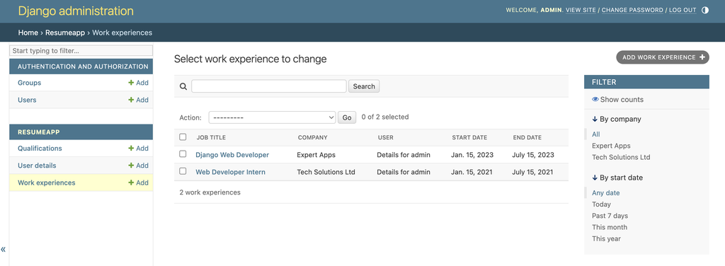

## Adding Custom Actions to the Admin Panel

In the Django admin panel, you can perform **actions** on multiple items at once. By default, the admin includes a “Delete selected” action that lets you bulk delete records.

But you’re not limited to just deleting—you can create your own custom actions. For example, instead of deleting records, you might want to **mark them as archived** by setting a `status` or `archived` flag.

You can read more about defining and customizing admin actions in the official Django docs:  
👉 [Django Admin Actions Documentation](https://docs.djangoproject.com/en/5.1/ref/contrib/admin/actions/)

Custom actions are a great way to speed up admin tasks and give your team more control over bulk operations.

🎉 **Congratulations! You’ve successfully configured the Django Admin!** 🚀